# Global Climate Change, Oregon Wildfires, and Portland Air Quality

Claire LeBlanc

### Background on fires and air quality in portland oregon

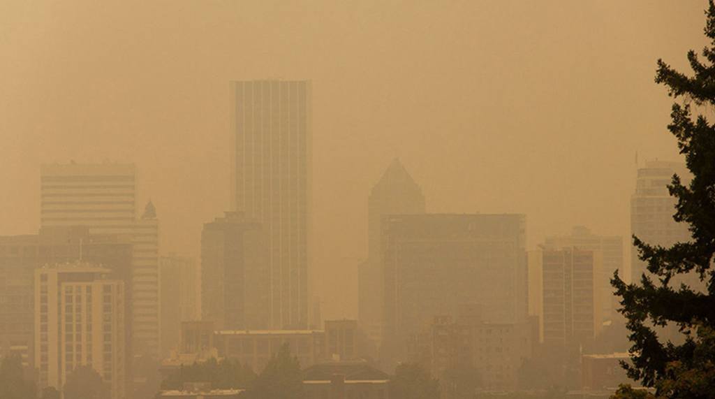

Smoke in Portland, OR due to Wildfires

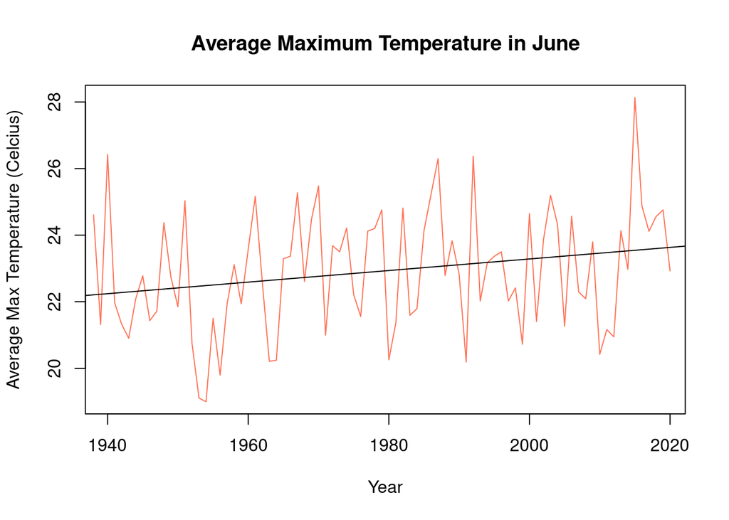

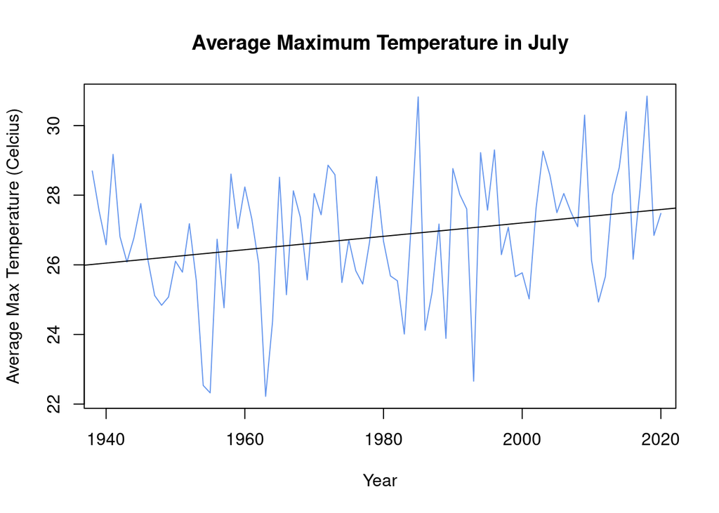

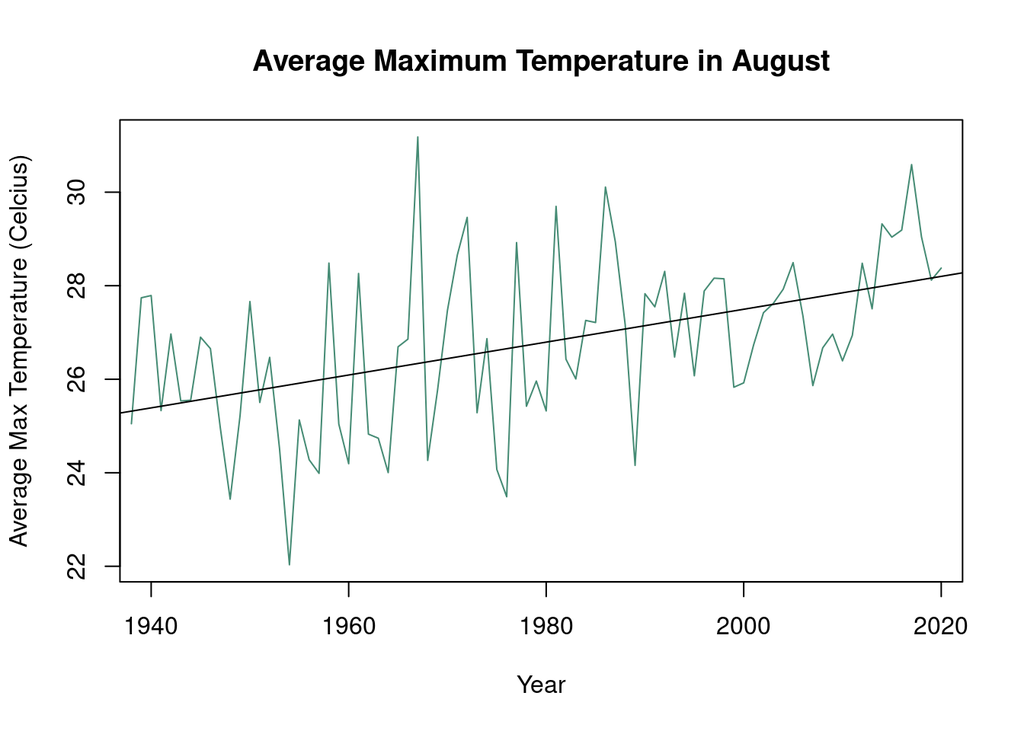

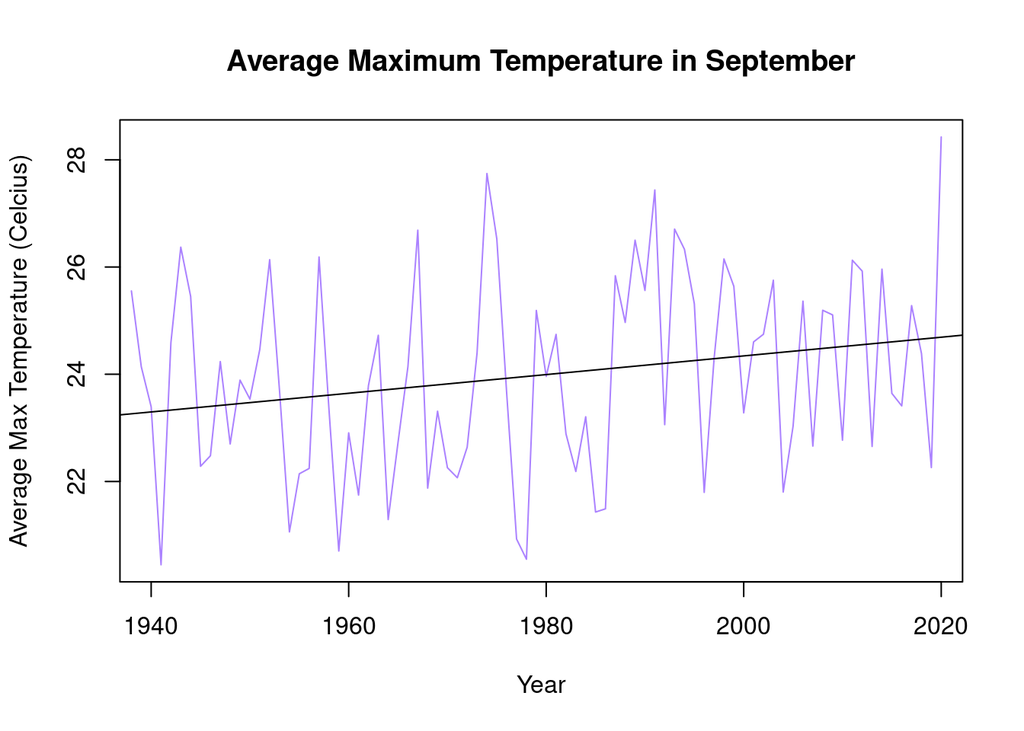

For all four months shown, the warming trend was found to be significant. For each month, the null hypothesis was that the slope of the trend line is zero (temperature is not increasing or decreasing over time). Additionally, we used a 95% confidence interval so when there is less than 5% probability that we would get this data if there was no relation (p < .05), we reject the null hypothesis.

For June, p = 0.03627 < 0.05 and adjusted r squared = 0.04132. Therefore, we reject the null hypothesis for June, concluding that there is a significant warming trend. We can also conclude that our linear model only accounts for about 4% of the variation seen in the data

For July, p = 0.0223 < 0.05 and the adjusted r squared = 0.0512. Therefore, we also reject the null hypothesis for July, concluding that there is a significant warming trend. We can also conclude that our linear model only accounts for about 5% of the variation seen in the data.

For August, p = 8.038 x 10^-6 < 0.05 and the adjusted r squared = 0.2096. Therefore, we also reject the null hypothesis for August, concluding that there is a significant warming trend. Additionally, in August, the linear model accounts for about 21% of the variation seen in the model, which is much more than the models accounted for in June and July.

For September, p = 0.03693 < 0.05 and Adjusted R-squared = 0.04095. Therefore, we can reject the null hypothesis for September, concluding that there is a significant warming trend. We can also conclude that our linear model only accounts for about 4% of the variation in the data.

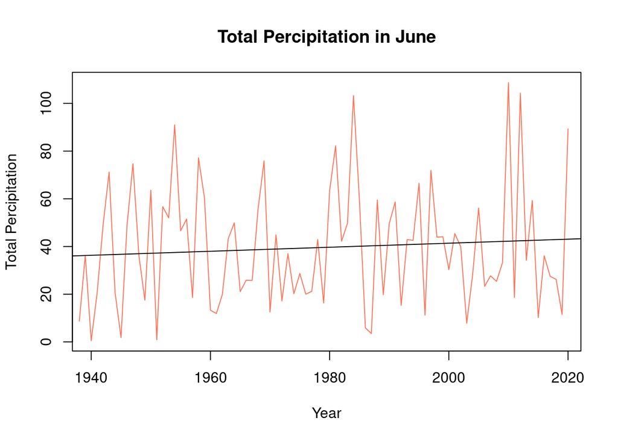

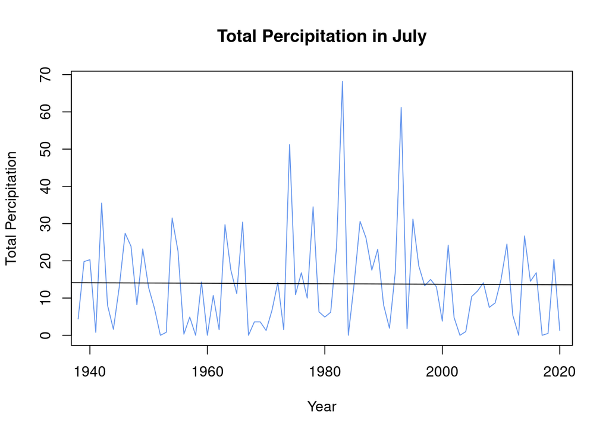

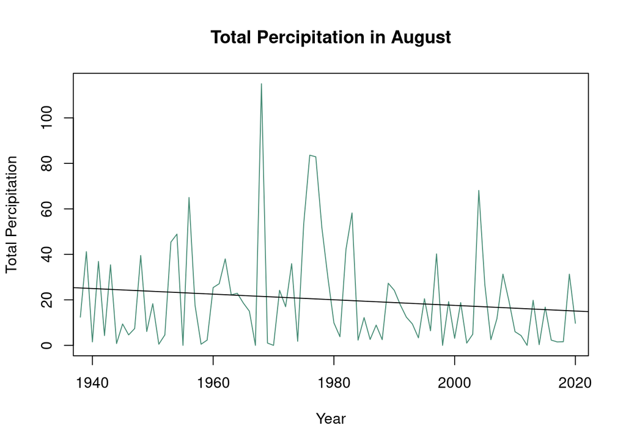

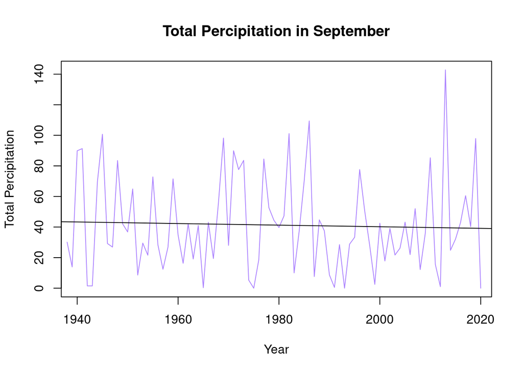

For the precipitation data, a 95% confidence interval was also used and our null hypothesis was that total monthly precipitation was not increasing or decreasing over time.

In July, although the linear model showed a slight decreasing trend, the trend is insignificant and we failed to reject the null hypothesis (p = 0.9143 > 0.05). The Adjusted R-squared value = -0.0122, so the model explains none of the variation.

In August, the decreasing trend was also not found to be significant and we failed to reject the null hypothesis (p = 0.2293 > 0.05). Additionally, Adjusted R-squared = 0.005668 so the model only accounts from 0.5% of the variation in the data.

Once again, in September, the decreasing trend was not found to be significant and we failed to reject the null hypothesis (p = 0.719 > 0.05). Additionally, Adjusted R-squared = -0.01072, so the model accounts for none of the variation in the data.

### Air Quality Data

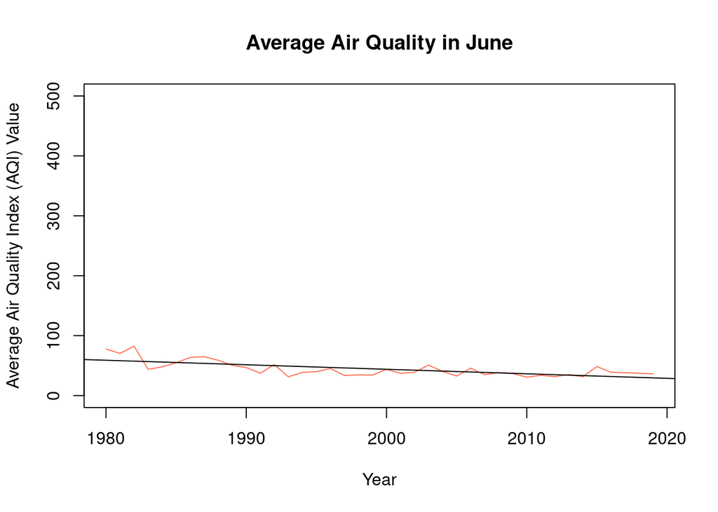

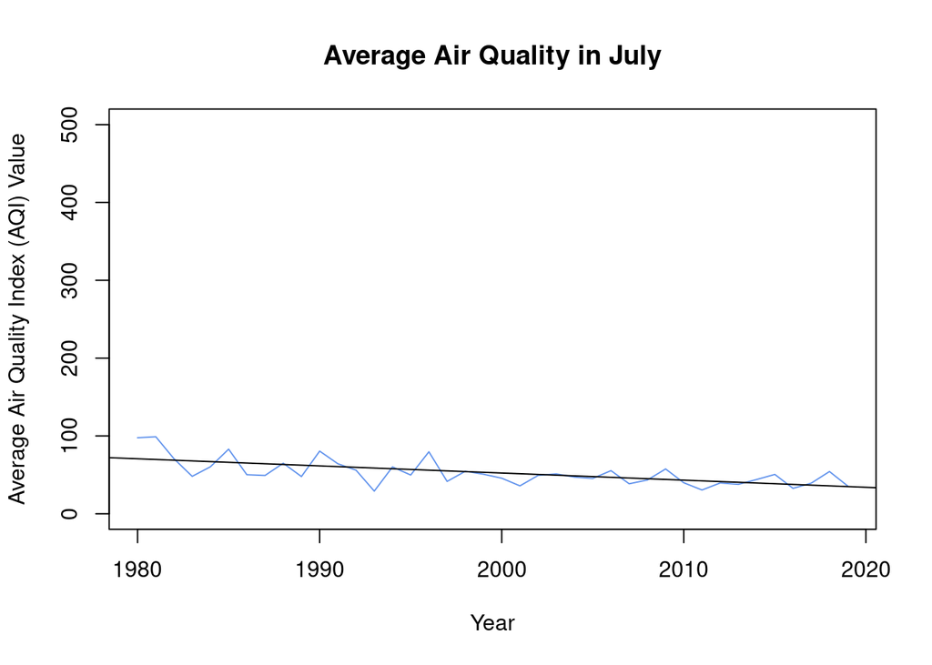

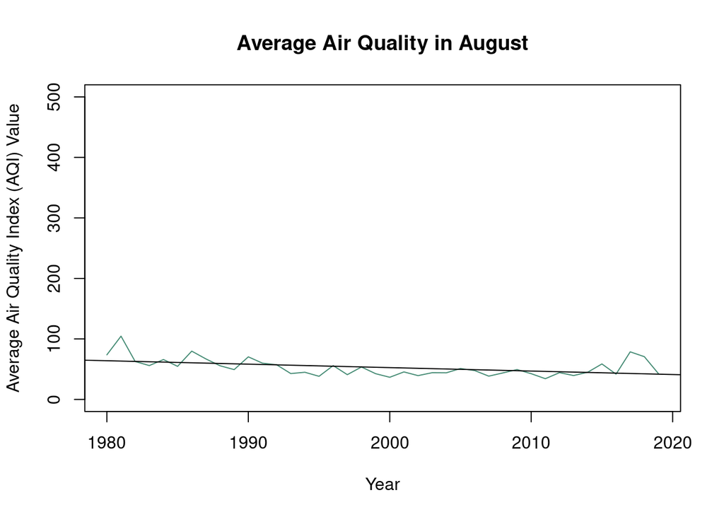

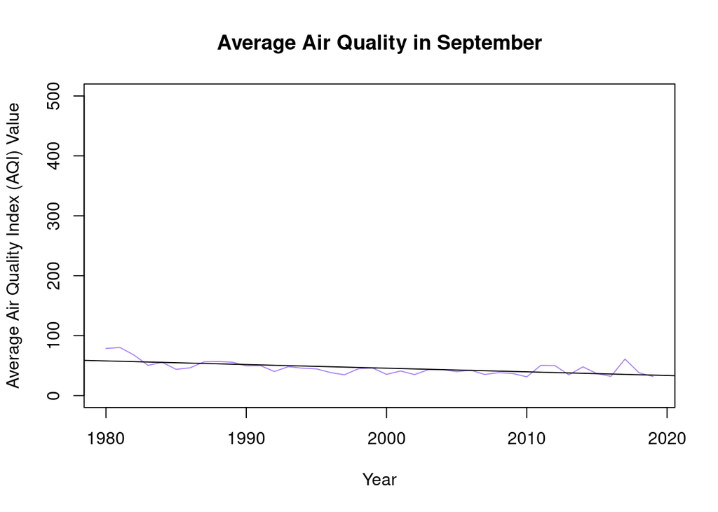

This is probably not the final way I will analyze the air quality data. I am hoping to figure out some way to graph the number of days that the air quality is above a certain level. Right now, all of the monthly air quality linear models show a significant downward trend. In my literature review, I found that air quality has been improving elsewhere in the US, so this trend may be occurring in Portland as well and cancelling out the increased smoke from fires. If this is the case, I may end up analyzing a different third aspect.